# Google Analytics Customer Revenue Prediction EDA

# 1 Introduction

Here is an Exploratory Data Analysis for the Google Analytics Customer Revenue Prediction competition within the R environment. For this EDA in the main we will use [tidyverse](https://www.tidyverse.org/packages/) packages. Also for modelling we will use [glmnet](https://web.stanford.edu/~hastie/glmnet/glmnet_alpha.html), [xgboost](https://cran.r-project.org/web/packages/xgboost/vignettes/xgboostPresentation.html) and [keras](https://keras.rstudio.com/) packages.

Our task is to build an algorithm that predicts the natural log of the sum of all transactions per user. Thus, for every user in the test set, the target is:

$$y_{user} = \sum_{i=1}^n transaction_{user_i}$$

$$target_{user} = ln(y_{user}+1).$$

Submissions are scored on the root mean squared error, which is defined as:

$$RMSE = \sqrt{\frac{1}{n} \sum_{i=1}^n (y_i - \widehat{y_i})^2},$$

where $\widehat{y}$ is the predicted revenue for a customer and $y$ is the natural log of the actual revenue value.

Let’s prepare and have a look at the dataset.

# 2 Preparations

## 2.1 Load libraries

Here we load libraries for data wrangling and visualisation.

```r
library(h2o)
library(caret)
library(lme4)
library(ggalluvial)
library(xgboost)
library(jsonlite)
library(lubridate)
library(knitr)
library(Rmisc)
library(scales)
library(countrycode)
library(highcharter)
library(glmnet)
library(keras)
library(forecast)
library(zoo)
library(magrittr)
library(tidyverse)
library(stringr)
library(forcats)
```

## 2.2 Load data

```r
set.seed(0)

tr <- read_csv("../input/train_s.csv")
te <- read_csv("../input/test_s.csv")
subm <- read_csv("../input/sample_submission.csv")
```

# 3 Peek at the dataset

## 3.1 General info

```
## Train set file size: 86330826 bytes
```

```
## Train set dimensions: 5694 13
```

```
## Observations: 5,694
## Variables: 13
## $ channelGrouping      <chr> "Organic Search", "Organic Search", "Orga...
## $ customDimensions     <chr> "[{'index': '4', 'value': 'North America'...
## $ date                 <int> 20171016, 20171016, 20171016, 20171016, 2...
## $ device               <chr> "{\"browser\": \"Safari\", \"browserVersi...
## $ fullVisitorId        <dbl> 5.200650e+18, 3.200002e+18, 9.066915e+18,...
## $ geoNetwork           <chr> "{\"continent\": \"Americas\", \"subConti...
## $ hits                 <chr> "[{'hitNumber': '1', 'time': '0', 'hour':...
## $ socialEngagementType <chr> "Not Socially Engaged", "Not Socially Eng...
## $ totals               <chr> "{\"visits\": \"1\", \"hits\": \"7\", \"p...
## $ trafficSource        <chr> "{\"campaign\": \"(not set)\", \"source\"...
## $ visitId              <int> 1508169977, 1508207702, 1508152302, 15081...
## $ visitNumber          <int> 2, 1, 1, 1, 1, 2, 2, 1, 1, 1, 3, 1, 5, 2,...
## $ visitStartTime       <int> 1508169977, 1508207702, 1508152302, 15081...
```

```
## Test set file size: 25175668 bytes
```

```
## Test set dimensions: 1338 13
```

```
## Observations: 1,338
## Variables: 13
## $ channelGrouping      <chr> "Organic Search", "Organic Search", "Orga...
## $ customDimensions     <chr> "[{'index': '4', 'value': 'South America'...
## $ date                 <int> 20180511, 20180511, 20180511, 20180511, 2...
## $ device               <chr> "{\"browser\": \"Chrome\", \"browserVersi...
## $ fullVisitorId        <dbl> 2.478621e+18, 7.711271e+17, 3.699492e+18,...
## $ geoNetwork           <chr> "{\"continent\": \"Americas\", \"subConti...
## $ hits                 <chr> "[{'hitNumber': '1', 'time': '0', 'hour':...
## $ socialEngagementType <chr> "Not Socially Engaged", "Not Socially Eng...
## $ totals               <chr> "{\"visits\": \"1\", \"hits\": \"13\", \"...
## $ trafficSource        <chr> "{\"referralPath\": \"(not set)\", \"camp...
## $ visitId              <int> 1526100413, 1526030584, 1526067726, 15260...
## $ visitNumber          <int> 1, 1, 1, 1, 1, 1, 1, 1, 1, 1, 1, 1, 2, 4,...
## $ visitStartTime       <int> 1526100413, 1526030584, 1526067726, 15260...
```

## 3.2 Distribution of transaction dates

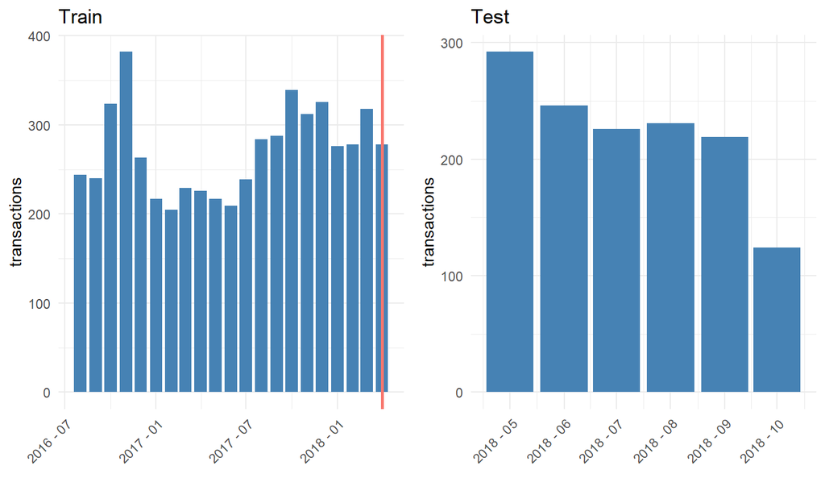

## 3.3 Dataset columns

There is a total of 13 features:

- **channelGrouping** - the channel via which the user came to the Store
- **customDimensions** - customer profile
- **date** - the date on which the user visited the Store
- **device** - the specifications for the device used to access the Store
- **fullVisitorId** - an unique identifier for each user of the Google Merchandise Store
- **geoNetwork** - this section contains information about the geography of the user
- **hits** - user actions during the session
- **socialEngagementType** - engagement type, either “Socially Engaged” or “Not Socially Engaged”
- **totals** - this section contains aggregate values across the session
- **trafficSource** - this section contains information about the Traffic Source from which the session originated
- **visitId** - an identifier for this session
- **visitNumber** - the session number for this user
- **visitStartTime** - the timestamp (POSIX).

Let’s have a look at counts of the simple features:

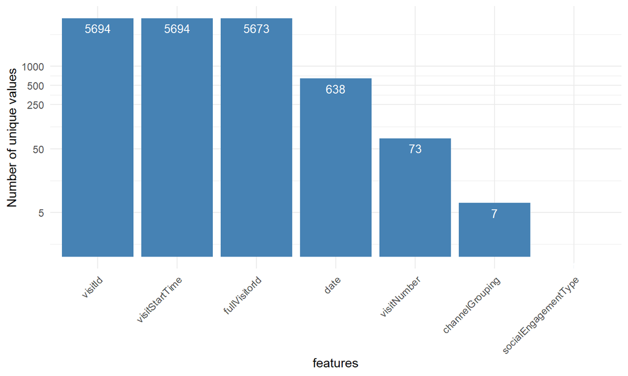

At least one column can be removed.

## 3.4 JSON data

Actually the columns **device**, **geoNetwork**, **trafficSource**, **totals**, **customDimensions**, **hits** contain data in JSON format. To parse it we can use [jsonlite](https://cran.r-project.org/web/packages/jsonlite/) package but due to inconsistency of the data form the **trafficSource** column we need some addional tricks. I suggest to use the code, which is based on [this idea](https://www.kaggle.com/mrlong/r-flatten-json-columns-to-make-single-data-frame):

```r
flatten_json <- . %>%
  str_c(., collapse = ",") %>%
  str_c("[", ., "]") %>%
  fromJSON(flatten = T)

parse <- . %>%
  bind_cols(flatten_json(.$customDimensions[0])) %>%
  bind_cols(flatten_json(.$hits[0])) %>%
  bind_cols(flatten_json(.$device)) %>%
  bind_cols(flatten_json(.$geoNetwork)) %>%
  bind_cols(flatten_json(.$trafficSource)) %>%
  bind_cols(flatten_json(.$totals)) %>%
  select(-customDimensions, -hits, -device, -geoNetwork, -trafficSource, -totals)
```

**str_c** function is a little faster than **paste()**.

Let’s convert train and test sets to the tidy format:

```r
tr <- parse(tr)
te <- parse(te)
```

## 3.5 Tidy datasets

### 3.5.1 Train

| channelGrouping | date | fullVisitorId | socialEngagementType | visitId | visitNumber | visitStartTime | browser | browserVersion | browserSize | operatingSystem | operatingSystemVersion | isMobile | mobileDeviceBranding | mobileDeviceModel | mobileInputSelector | mobileDeviceInfo | mobileDeviceMarketingName | flashVersion | language | screenColors | screenResolution | deviceCategory | continent | subContinent | country | region | metro | city | cityId | … |
| --- | --- | --- | --- | --- | --- | --- | --- | --- | --- | --- | --- | --- | --- | --- | --- | --- | --- | --- | --- | --- | --- | --- | --- | --- | --- | --- | --- | --- | --- | --- |
| Organic Search | 20171016 | 5.200650e+18 | Not Socially Engaged | 1508169977 | 2 | 1508169977 | Safari | not available in demo dataset | not available in demo dataset | iOS | not available in demo dataset | TRUE | not available in demo dataset | not available in demo dataset | not available in demo dataset | not available in demo dataset | not available in demo dataset | not available in demo dataset | not available in demo dataset | not available in demo dataset | not available in demo dataset | mobile | Americas | Northern America | Canada | not available in demo dataset | not available in demo dataset | not available in demo dataset | not available in demo dataset | … |
| Organic Search | 20171016 | 3.200002e+18 | Not Socially Engaged | 1508207702 | 1 | 1508207702 | Chrome | not available in demo dataset | not available in demo dataset | Windows | not available in demo dataset | FALSE | not available in demo dataset | not available in demo dataset | not available in demo dataset | not available in demo dataset | not available in demo dataset | not available in demo dataset | not available in demo dataset | not available in demo dataset | not available in demo dataset | desktop | Americas | Northern America | Canada | not available in demo dataset | not available in demo dataset | not available in demo dataset | not available in demo dataset | … |

### 3.5.2 Test

| channelGrouping | date | fullVisitorId | socialEngagementType | visitId | visitNumber | visitStartTime | browser | browserVersion | browserSize | operatingSystem | operatingSystemVersion | isMobile | mobileDeviceBranding | mobileDeviceModel | mobileInputSelector | mobileDeviceInfo | mobileDeviceMarketingName | flashVersion | language | screenColors | screenResolution | deviceCategory | continent | subContinent | country | region | metro | city | cityId | … |
| --- | --- | --- | --- | --- | --- | --- | --- | --- | --- | --- | --- | --- | --- | --- | --- | --- | --- | --- | --- | --- | --- | --- | --- | --- | --- | --- | --- | --- | --- | --- |
| Organic Search | 20180511 | 2.478621e+18 | Not Socially Engaged | 1526100413 | 1 | 1526100413 | Chrome | not available in demo dataset | not available in demo dataset | Android | not available in demo dataset | TRUE | not available in demo dataset | not available in demo dataset | not available in demo dataset | not available in demo dataset | not available in demo dataset | not available in demo dataset | not available in demo dataset | not available in demo dataset | not available in demo dataset | mobile | Americas | South America | Brazil | State of Parana | (not set) | Curitiba | not available in demo dataset | … |
| Organic Search | 20180511 | 7.711271e+17 | Not Socially Engaged | 1526030584 | 1 | 1526030584 | Chrome | not available in demo dataset | not available in demo dataset | Android | not available in demo dataset | TRUE | not available in demo dataset | not available in demo dataset | not available in demo dataset | not available in demo dataset | not available in demo dataset | not available in demo dataset | not available in demo dataset | not available in demo dataset | not available in demo dataset | mobile | Asia | Western Asia | Lebanon | not available in demo dataset | not available in demo dataset | not available in demo dataset | not available in demo dataset | … |

### 3.5.3 Sample Submission

| fullVisitorId | PredictedLogRevenue |
| --- | --- |
| 2.47862e+18 | 0 |
| 7.71127e+17 | 0 |
| 3.69949e+18 | 0 |
| 1.63351e+18 | 0 |
| 3.17000e+18 | 0 |

## 3.6 Train and test features sets intersection

```r
# setdiff(names(tr), names(te))
tr %<>% select(-one_of("transactions"))
tr %<>% select(-one_of("totalTransactionRevenue"))
te %<>% select(-one_of("transactions"))
te %<>% select(-one_of("totalTransactionRevenue"))
te %<>% select(-one_of("transactionRevenue"))

setdiff(names(tr), names(te))
```

```
## [1] "transactionRevenue"
```

The test set lacks one columns, which is a target variable **transactionRevenue**.

## 3.7 Constant columns

Let’s find constant columns:

```r
fea_uniq_values <- sapply(tr, n_distinct)
(fea_del <- names(fea_uniq_values[fea_uniq_values == 1]))
```

```
##  [1] "socialEngagementType"
##  [2] "browserVersion"
##  [3] "browserSize"
##  [4] "operatingSystemVersion"
##  [5] "mobileDeviceBranding"
##  [6] "mobileDeviceModel"
##  [7] "mobileInputSelector"
##  [8] "mobileDeviceInfo"
##  [9] "mobileDeviceMarketingName"
## [10] "flashVersion"
## [11] "language"
## [12] "screenColors"
## [13] "screenResolution"
## [14] "cityId"
## [15] "latitude"
## [16] "longitude"
## [17] "networkLocation"
## [18] "adwordsClickInfo.criteriaParameters"
## [19] "visits"
```

```r
tr %<>% select(-one_of(fea_del))
te %<>% select(-one_of(fea_del))
```

All these useless features we can safely remove.

## 3.8 Expanded train features

```r
names(tr)
```

```
##  [1] "channelGrouping"                "date"
##  [3] "fullVisitorId"                  "visitId"
##  [5] "visitNumber"                    "visitStartTime"
##  [7] "browser"                        "operatingSystem"
##  [9] "isMobile"                       "deviceCategory"
## [11] "continent"                      "subContinent"
## [13] "country"                        "region"
## [15] "metro"                          "city"
## [17] "networkDomain"                  "campaign"
## [19] "source"                         "medium"
## [21] "keyword"                        "isTrueDirect"
## [23] "adContent"                      "referralPath"
## [25] "adwordsClickInfo.page"          "adwordsClickInfo.slot"
## [27] "adwordsClickInfo.gclId"         "adwordsClickInfo.adNetworkType"
## [29] "adwordsClickInfo.isVideoAd"     "hits1"
## [31] "pageviews"                      "timeOnSite"
## [33] "sessionQualityDim"              "newVisits"
## [35] "bounces"                        "transactionRevenue"
```

```r
# names(te)
```

## 3.9 Missing values

After parsing of the JSON data we can observe many missing values in the data set. Let’s find out how many missing values each feature has. We need to take into account that such values as “not available in demo dataset”, “(not set)”, “unknown.unknown”, “(not provided)” can be treated as NA.

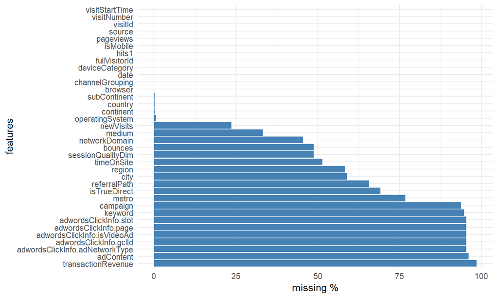

```r
is_na_val <- function(x) x %in% c("not available in demo dataset", "(not provided)",
                                  "(not set)", "<NA>", "unknown.unknown",  "(none)")

tr %<>% mutate_all(list(~ifelse(is_na_val(.), NA, .)))
te %<>% mutate_all(list(~ifelse(is_na_val(.), NA, .)))
```

There is a bunch of features missing nearly completely.

## 3.10 data transformations

We need to convert some features to their natural representation.

```r
tr[0:3,]
```

```
## # A tibble: 3 x 36
##   channelGrouping   date fullVisitorId visitId visitNumber visitStartTime
##   <chr>            <int>         <dbl>   <int>       <int>          <int>
## 1 Organic Search  2.02e7       5.20e18  1.51e9           2     1508169977
## 2 Organic Search  2.02e7       3.20e18  1.51e9           1     1508207702
## 3 Organic Search  2.02e7       9.07e18  1.51e9           1     1508152302
## # ... with 30 more variables: browser <chr>, operatingSystem <chr>,
## #   isMobile <lgl>, deviceCategory <chr>, continent <chr>,
## #   subContinent <chr>, country <chr>, region <chr>, metro <chr>,
## #   city <chr>, networkDomain <chr>, campaign <chr>, source <chr>,
## #   medium <chr>, keyword <chr>, isTrueDirect <lgl>, adContent <chr>,
## #   referralPath <chr>, adwordsClickInfo.page <chr>,
## #   adwordsClickInfo.slot <chr>, adwordsClickInfo.gclId <chr>,
## #   adwordsClickInfo.adNetworkType <chr>,
## #   adwordsClickInfo.isVideoAd <lgl>, hits1 <chr>, pageviews <chr>,
## #   timeOnSite <chr>, sessionQualityDim <chr>, newVisits <chr>,
## #   bounces <chr>, transactionRevenue <chr>
```

```r
te[0:3,]
```

```
## # A tibble: 3 x 35
##   channelGrouping   date fullVisitorId visitId visitNumber visitStartTime
##   <chr>            <int>         <dbl>   <int>       <int>          <int>
## 1 Organic Search  2.02e7       2.48e18  1.53e9           1     1526100413
## 2 Organic Search  2.02e7       7.71e17  1.53e9           1     1526030584
## 3 Organic Search  2.02e7       3.70e18  1.53e9           1     1526067726
## # ... with 29 more variables: browser <chr>, operatingSystem <chr>,
## #   isMobile <lgl>, deviceCategory <chr>, continent <chr>,
## #   subContinent <chr>, country <chr>, region <chr>, metro <chr>,
## #   city <chr>, networkDomain <chr>, referralPath <chr>, campaign <chr>,
## #   source <chr>, medium <chr>, keyword <chr>, adContent <chr>,
## #   isTrueDirect <lgl>, adwordsClickInfo.page <chr>,
## #   adwordsClickInfo.slot <chr>, adwordsClickInfo.gclId <chr>,
## #   adwordsClickInfo.adNetworkType <chr>,
## #   adwordsClickInfo.isVideoAd <lgl>, hits1 <chr>, pageviews <chr>,
## #   timeOnSite <chr>, newVisits <chr>, sessionQualityDim <chr>,
## #   bounces <chr>
```

```r
tr %<>%
  mutate(date = ymd(date),
         hits = as.integer(hits1),
         pageviews = as.integer(pageviews),
         bounces = as.integer(bounces),
         newVisits = as.integer(newVisits),
         transactionRevenue = as.numeric(transactionRevenue))
tr %<>% select(-one_of("hits1"))

te %<>%
  mutate(date = ymd(date),
         hits = as.integer(hits1),
         pageviews = as.integer(pageviews),
         bounces = as.integer(bounces),
         newVisits = as.integer(newVisits))
te %<>% select(-one_of("hits1"))
```

## 3.11 Target variable

As a target variable we use **transactionRevenue** which is a sub-column of the **totals** JSON column. It looks like this variable is multiplied by $10^6$.

```r
y <- tr$transactionRevenue
tr$transactionRevenue <- NULL
summary(y)
```

```
##      Min.   1st Qu.    Median      Mean   3rd Qu.      Max.      NA's
## 1.590e+06 2.888e+07 6.929e+07 1.413e+08 1.472e+08 2.548e+09      5611
```

We can safely replace **NA** values with 0.

```r
y[is.na(y)] <- 0
summary(y)
```

```
##      Min.   1st Qu.    Median      Mean   3rd Qu.      Max.
## 0.000e+00 0.000e+00 0.000e+00 2.059e+06 0.000e+00 2.548e+09
```

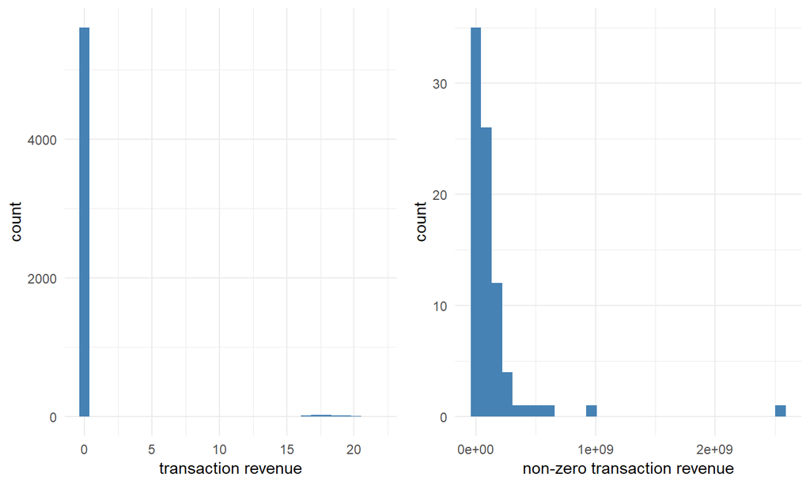

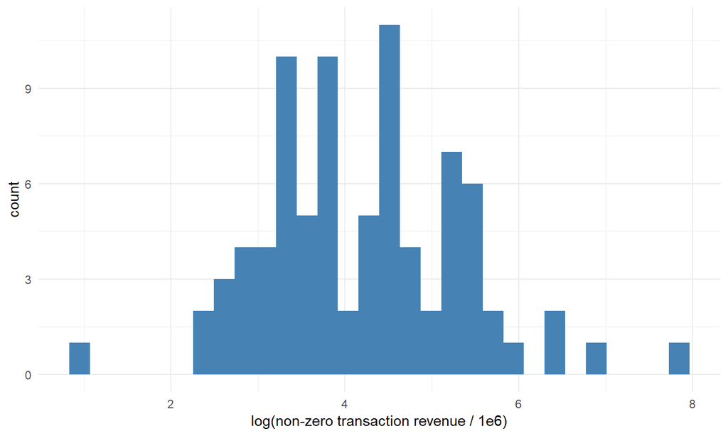

The target variable has a wide range of values. Its distribution is right-skewed. For modelling we will use log-transformed target.

Only 1.46% of all transactions have non-zero revenue:

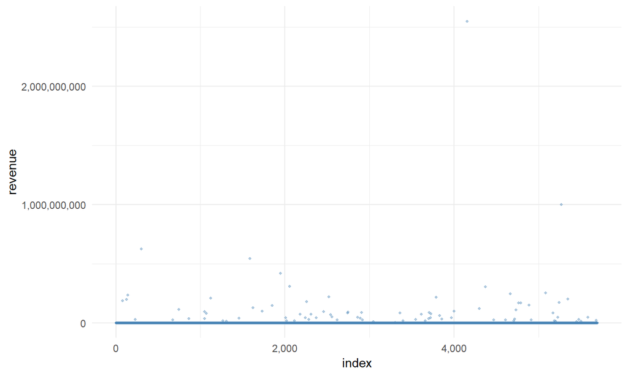

The next figure shows that users who came via **Affiliates** and **Social** channels do not generate revenue. The most profitable channel is **Referral**:

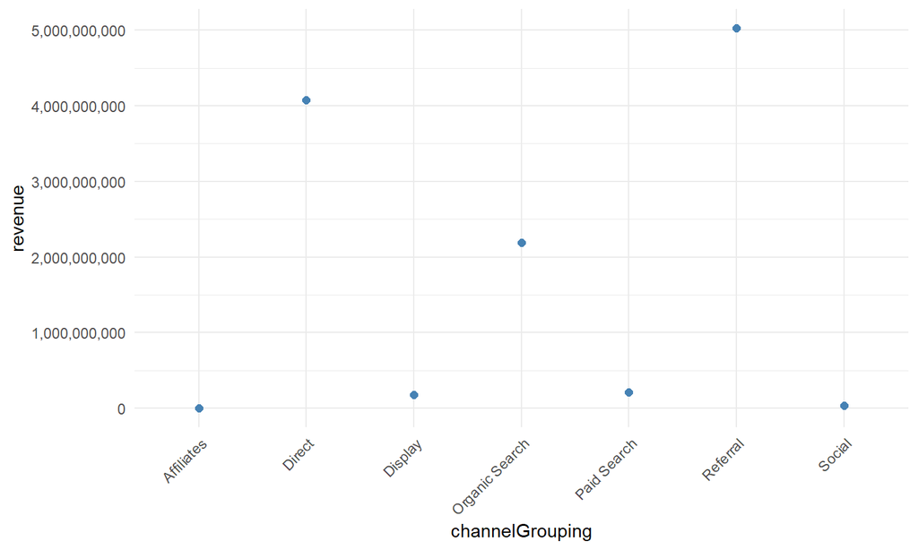

Also usually first/less visit users generate more total revenue:

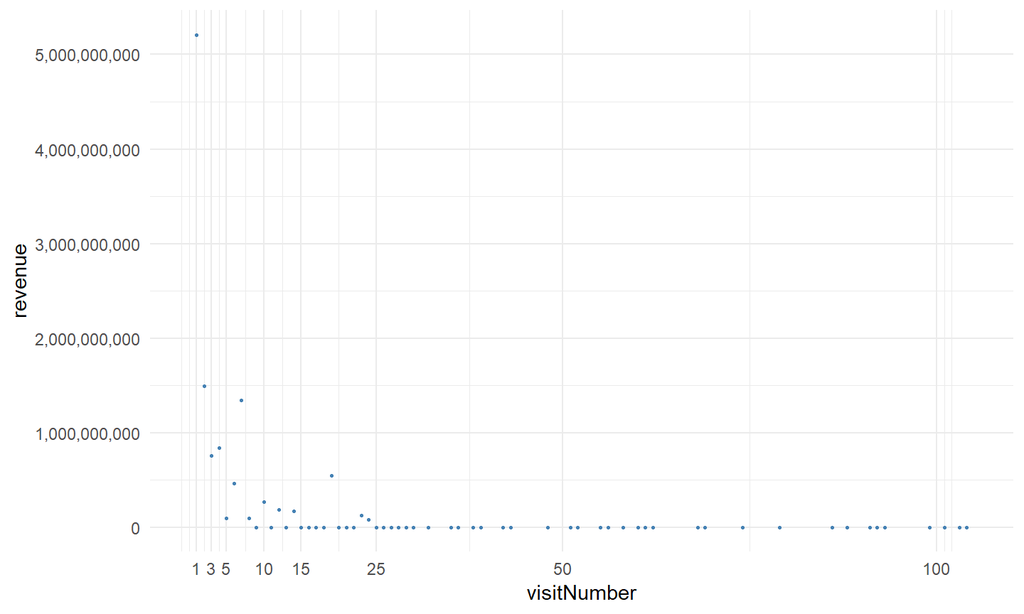

## 3.12 How target variable changes in time

The revenue itself can be viewed as a timeseries. There seems to be a pattern of peaks.

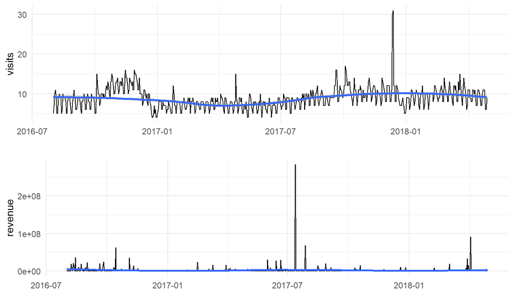

## 3.13 Distribution of visits and revenue by attributes

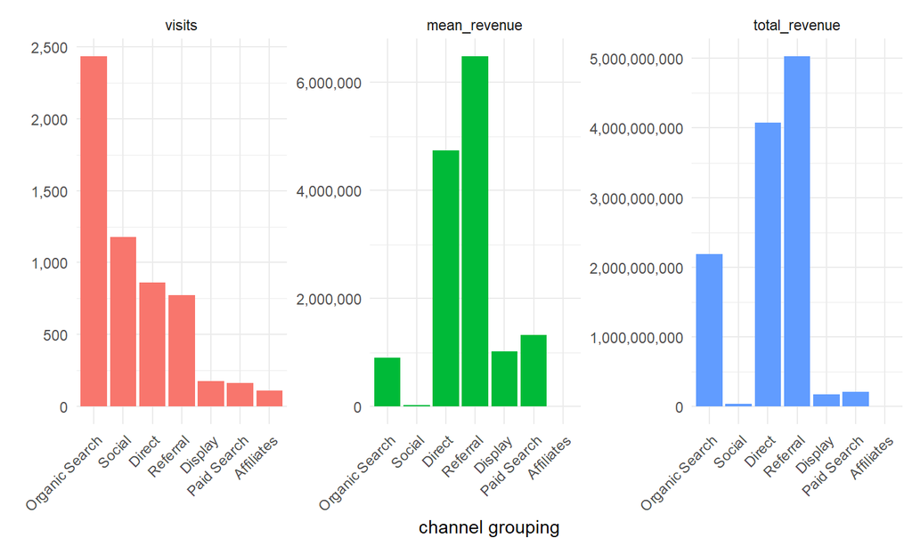

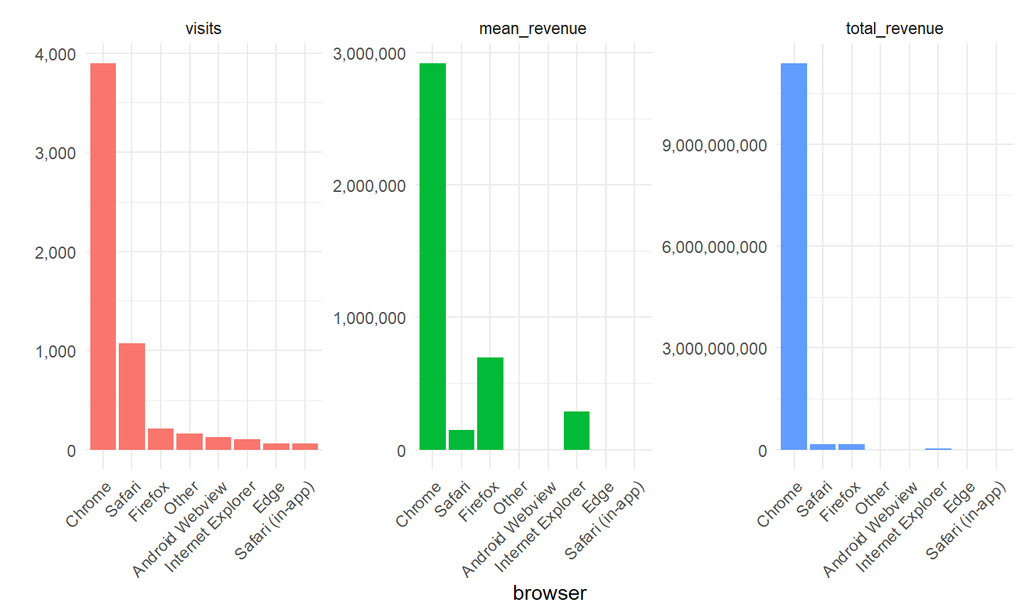

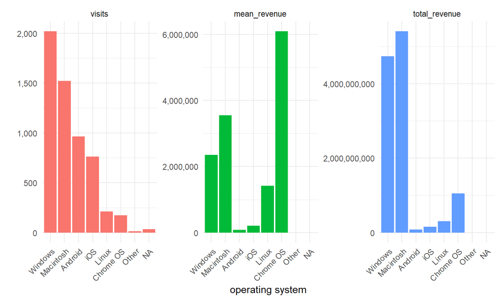

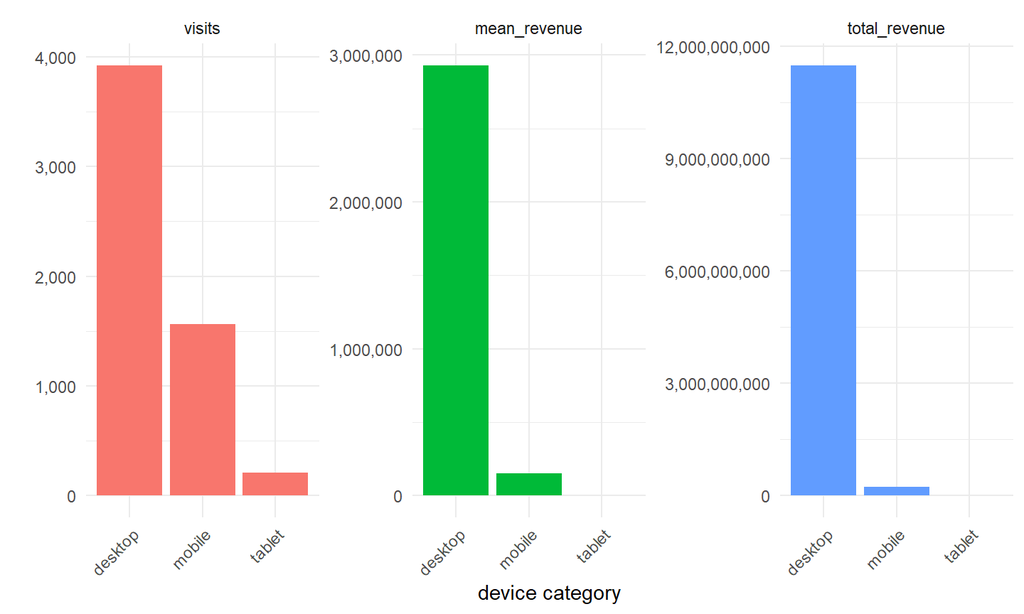

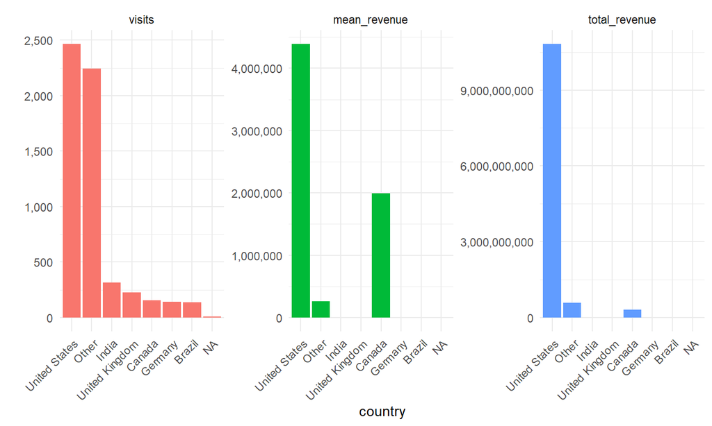

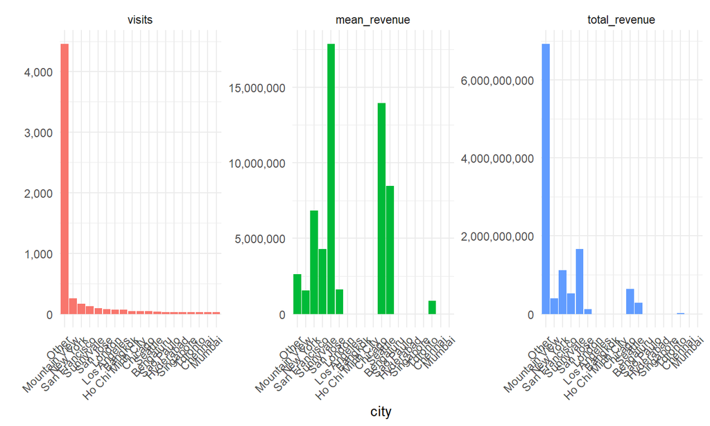

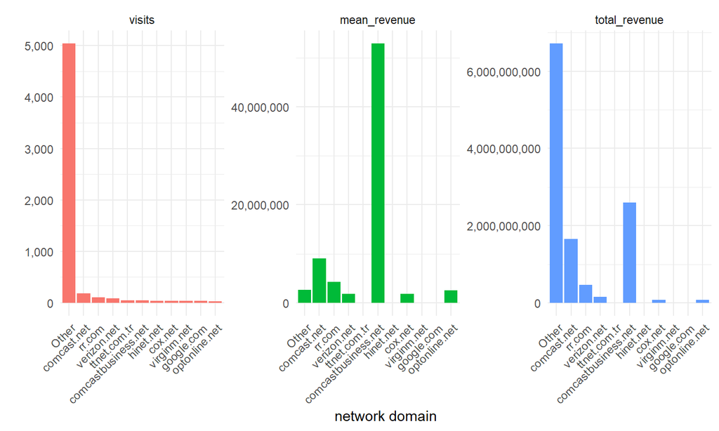

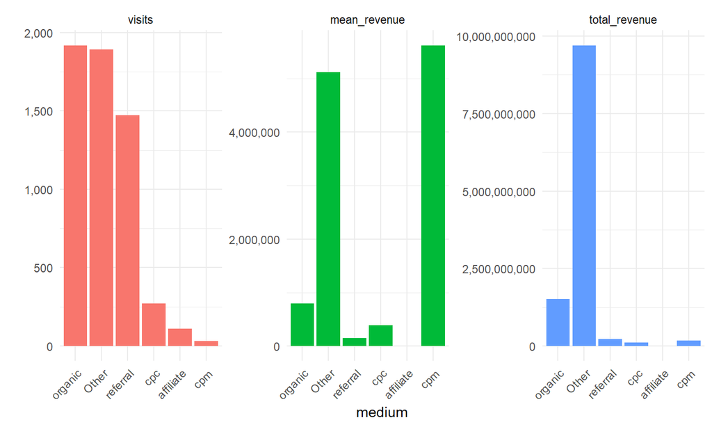

## 3.14 Findings:

- The most frequent channels are **OrganicSearch** and **Social**.
- Chrome is the most popular browser and its users produce the highest total revenue.
- Windows and MacOS are the most popular operating systems. It’s interesting that ChromeOS users yield the highest mean revenue.
- Desktops are still in the ranks.
- The US users yield the most of the total revenue.
- Usually netwok domain is unknown.
- **organic** and **referral** are the most popular mediums.

# 4 Alluvial diagram

This kind of plot is useful for discovering of multi-feature interactions. The vertical size of each block is proportional to the frequency of the feature. The figure shows the flows for the case when revenue > 0:

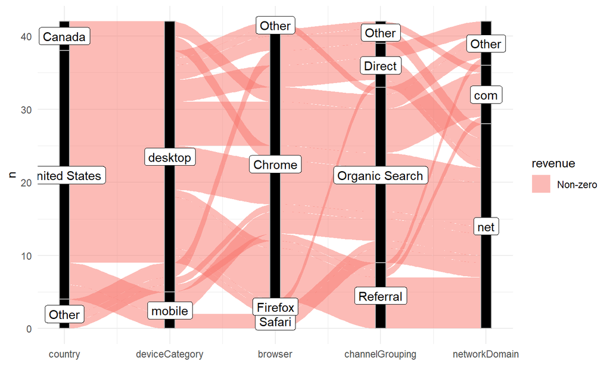

Non-zero transaction revenue in the main is yielded by the flow US-desktop-Chrome-{OrganicSearch | Referral}-net.

# 5 Correlations between revenue and features

Some features are categorical and we reencode them as OHE (with reduced set of levels). The ID columns are dropped.

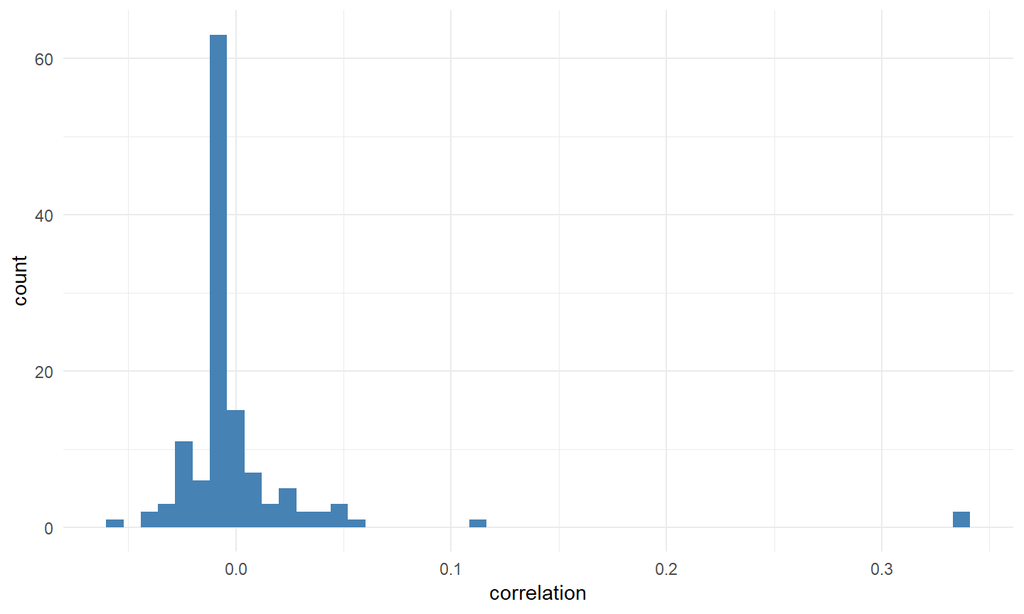

```r
m <- tr %>%
  mutate(year = year(date),
         month = month(date),
         day = day(date),
         isMobile = ifelse(isMobile, 1L, 0L),
         isTrueDirect = ifelse(isMobile, 1L, 0L)) %>%
  mutate_all(funs(ifelse(is.na(.), 0, .))) %>%
  select(-date, -fullVisitorId, -visitId) %>%
  mutate_if(is.character, factor) %>%
  mutate_if(is.factor, fct_lump, prop = 0.01) %>%
  model.matrix(~ . - 1, .) %>%
  cor(y) %>%
  data.table::as.data.table(keep.rownames=TRUE) %>%
  set_names("Feature", "rho") %>%
  arrange(-rho)

m %>%
  ggplot(aes(x = rho)) +
  geom_histogram(bins = 50, fill="steelblue") +
  labs(x = "correlation") +
  theme_minimal()
```

The values of the correlation coefficient are concentrated around zero, but there are several values bigger than 0.3:

```r
m %>%
  filter(rho > 0.3) %>%
  kable()
```

| Feature | rho |
| --- | --- |
| hits | 0.3409752 |
| pageviews | 0.3370342 |

Let’s visualize the relationship of the target variable with each of the correlated variables.

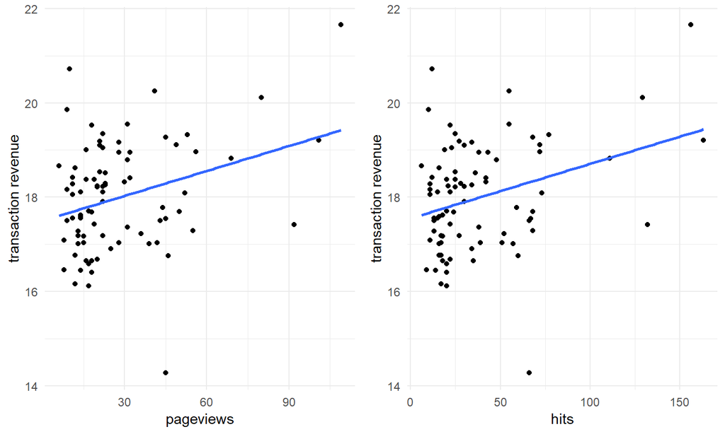

Here we observe weak positive relationship. Although, these features can play important role in a statistical model.

# 6 Revenue Predictive models

It is always useful to create several analtical models and compare them. Here for all models we use a preprocessed dataset:

```r
grp_mean <- function(x, grp) ave(x, grp, FUN = function(x) mean(x, na.rm = TRUE))

idx <- tr$date < ymd("20171201")
id <- te[, "fullVisitorId"]
tri <- 1:nrow(tr)

tr_te <- tr %>%
  bind_rows(te) %>%
  mutate(year = year(date) %>% factor(),
         wday = wday(date) %>% factor(),
         hour = hour(as_datetime(visitStartTime)) %>% factor(),
         isMobile = ifelse(isMobile, 1L, 0L),
         isTrueDirect = ifelse(isTrueDirect, 1L, 0L),
         adwordsClickInfo.isVideoAd = ifelse(!adwordsClickInfo.isVideoAd, 0L, 1L)) %>%
  select(-date, -fullVisitorId, -visitId, -visitStartTime, -sessionQualityDim, -timeOnSite) %>%
  mutate_if(is.character, factor) %>%
  mutate(pageviews_mean_vn = grp_mean(pageviews, visitNumber),
         pageviews_mean_country = grp_mean(pageviews, country),
         pageviews_mean_city = grp_mean(pageviews, city),
         pageviews_mean_dom = grp_mean(pageviews, networkDomain),
         pageviews_mean_ref = grp_mean(pageviews, referralPath)) %T>%
  glimpse()
```

```
## Observations: 7,032
## Variables: 37
## $ channelGrouping                <fct> Organic Search, Organic Search,...
## $ visitNumber                    <int> 2, 1, 1, 1, 1, 2, 2, 1, 1, 1, 3...
## $ browser                        <fct> Safari, Chrome, Chrome, Chrome,...
## $ operatingSystem                <fct> iOS, Windows, Windows, Windows,...
## $ isMobile                       <int> 1, 0, 0, 0, 0, 1, 0, 1, 0, 0, 0...
## $ deviceCategory                 <fct> mobile, desktop, desktop, deskt...
## $ continent                      <fct> Americas, Americas, Europe, Asi...
## $ subContinent                   <fct> Northern America, Northern Amer...
## $ country                        <fct> Canada, Canada, Portugal, India...
## $ region                         <fct> NA, NA, NA, NA, NA, Riyadh Prov...
## $ metro                          <fct> NA, NA, NA, NA, NA, NA, New Yor...
## $ city                           <fct> NA, NA, NA, NA, NA, Riyadh, New...
## $ networkDomain                  <fct> NA, NA, vodafone.pt, NA, as9105...
```

[output cut: 24 more lines]

```r
# rm(tr, te, tr_ae, te_ae); invisible(gc())
```

## 6.1 GLMNET - Generalized linear model

For the **glmnet** model we need a model matrix. We replace **NA** values with zeros, rare factor levels are lumped:

```r
tr_te_ohe <- tr_te %>%
  mutate_if(is.factor, fct_explicit_na) %>%
  mutate_if(is.numeric, funs(ifelse(is.na(.), 0L, .))) %>%
  mutate_if(is.factor, fct_lump, prop = 0.05) %>%
  select(-adwordsClickInfo.isVideoAd) %>%
  model.matrix(~.-1, .) %>%
  scale() %>%
  round(4)

X <- tr_te_ohe[tri, ]
X_test <- tr_te_ohe[-tri, ]
rm(tr_te_ohe); invisible(gc())
```

```r
m_glm <- cv.glmnet(X, log1p(y), alpha = 0, family="gaussian",
                   type.measure = "mse", nfolds = 5)
```

```r
pred_glm_tr <- predict(m_glm, X, s = "lambda.min") %>% c()
pred_glm <- predict(m_glm, X_test, s = "lambda.min") %>% c()
sub <- "glmnet_gs.csv"
# submit(pred_glm)
pred_glm[0:10]
```

```
##  [1]  0.74372371 -0.39662964 -0.12616842  0.06407258 -0.31940026
##  [6] -0.12545581 -0.13612285 -0.19296770  0.79437261 -0.10595989
```

```r
rm(m_glm); invisible(gc())
```

## 6.2 XGB - Gradient boosting decision trees

At last, we are ready to create an XGB model. First, we need to preprocess the dataset. We don’t care about **NA** values - XGB handles them by default:

```r
tr_te_xgb <- tr_te %>%
  mutate_if(is.factor, as.integer) %>%
  glimpse()
```

```
## Observations: 7,032
## Variables: 37
## $ channelGrouping                <int> 4, 4, 4, 4, 4, 3, 2, 4, 4, 4, 1...
## $ visitNumber                    <int> 2, 1, 1, 1, 1, 2, 2, 1, 1, 1, 3...
## $ browser                        <int> 15, 5, 5, 5, 15, 5, 5, 15, 5, 9...
## $ operatingSystem                <int> 4, 10, 10, 10, 6, 1, 10, 4, 6, ...
## $ isMobile                       <int> 1, 0, 0, 0, 0, 1, 0, 1, 0, 0, 0...
## $ deviceCategory                 <int> 2, 1, 1, 1, 1, 2, 1, 2, 1, 1, 1...
## $ continent                      <int> 2, 2, 4, 3, 4, 3, 2, 2, 2, 4, 4...
## $ subContinent                   <int> 11, 11, 17, 16, 12, 19, 11, 11,...
## $ country                        <int> 22, 22, 100, 52, 130, 107, 131,...
## $ region                         <int> NA, NA, NA, NA, NA, 147, 121, N...
## $ metro                          <int> NA, NA, NA, NA, NA, NA, 35, NA,...
## $ city                           <int> NA, NA, NA, NA, NA, 217, 176, N...
## $ networkDomain                  <int> NA, NA, 1241, NA, 82, NA, NA, 1...
```

[output cut: 24 more lines]

```r
rm(tr_te); invisible(gc())
```

Second, we create train, validation and test sets. We use time-based split:

```r
dtest <- xgb.DMatrix(data = data.matrix(tr_te_xgb[-tri, ]))
tr_te_xgb <- tr_te_xgb[tri, ]
dtr <- xgb.DMatrix(data = data.matrix(tr_te_xgb[idx, ]), label = log1p(y[idx]))
dval <- xgb.DMatrix(data = data.matrix(tr_te_xgb[!idx, ]), label = log1p(y[!idx]))
dtrain <- xgb.DMatrix(data = data.matrix(tr_te_xgb), label = log1p(y))
cols <- colnames(tr_te_xgb)
rm(tr_te_xgb); invisible(gc)
```

The next step is to train the model:

```r
p <- list(objective = "reg:linear",
          booster = "gbtree",
          eval_metric = "rmse",
          nthread = 4,
          eta = 0.05,
          max_depth = 7,
          min_child_weight = 5,
          gamma = 0,
          subsample = 0.8,
          colsample_bytree = 0.7,
          colsample_bylevel = 0.6,
          nrounds = 2000)

set.seed(0)
m_xgb <- xgb.train(p, dtr, p$nrounds, list(val = dval), print_every_n = 100, early_stopping_rounds = 100)
```

[output not shown]

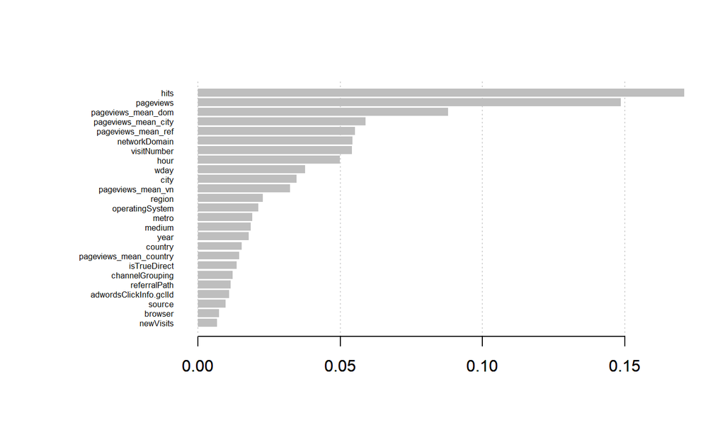

```r
xgb.importance(cols, model = m_xgb) %>%
  xgb.plot.importance(top_n = 25)
```

Finally, we make predictions:

```r
pred_xgb_tr <- predict(m_xgb, dtrain)
pred_xgb <- predict(m_xgb, dtest)
sub <- "xgb_gs.csv"
# submit(pred_xgb)
pred_xgb[0:10]
```

```
##  [1] 0.42952833 0.02526203 0.02526203 0.02508491 0.02526203 0.02575189
##  [7] 0.02151471 0.02526203 0.03711125 0.02526203
```

```r
rm(dtr, dtrain, dval, dtest, m_xgb); invisible(gc)
```

As it was stated earlier, **hits** and **pageviews** plays important roles in the XGB model.

## 6.3 Distributions of predictions

Let’s compare predictions for the train set:

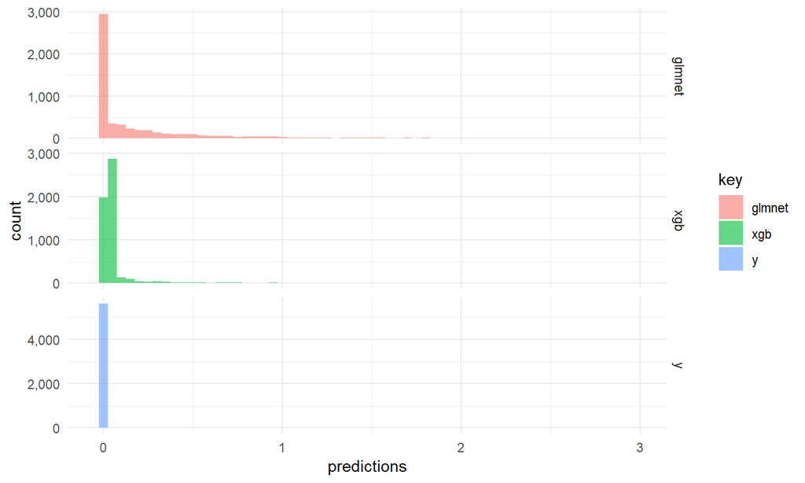

As we can see the distributions of the predictions are quite different. The XGB model tends to produce more narrow interval - closer to the true distribution.

```r
pred_avg <- log1p((expm1(pred_glm) + expm1(pred_xgb)) / 2)
sub <- "avg_gs.csv"
# submit(pred_xgb)
```

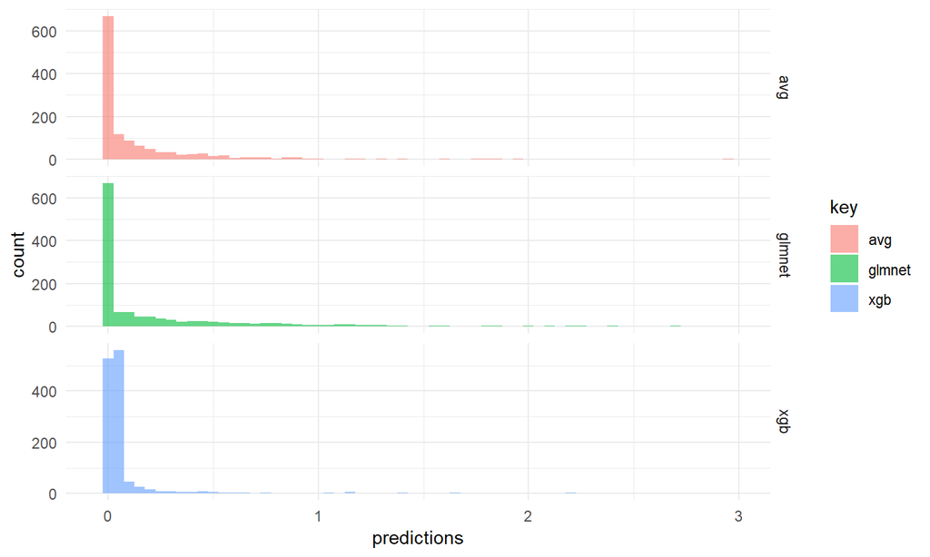

Distributions of the predictions for the test set differ much too, nevertheless after proper tuning of the models they can be useful for ensembling.

## 6.4 Output/Write results to csv:

```r
tr_dollar <- y/(10^6)
te_dollar <- exp(pred_avg)

tr_actl <- cbind(tr, tr_dollar)
te_pred <- cbind(te, te_dollar)

write_csv(tr_actl, "../output/tr_actl.csv")
write_csv(te_pred, "../output/te_pred.csv")
```

The End…